# STAT 184 Homework Exercises

DataComputing Chapters 1 & 2

Tanav Thanjavuru

## Assigned Exercises

- DC Chapter 1 Exercises: 1.1, 1.2, 1.3, 1.4, 1.5
- DC Chapter 2 Exercises: 2.1, 2.2, 2.3, 2.4, 2.5, 2.6, 2.8, 2.9

## Front Matter

```r
# clean up workspace environment
rm(list = ls())

# all packages used for the assignment
library(mosaic)
library(tidyverse)
```

## Chapter 1 Exercises

### Problem 1.1

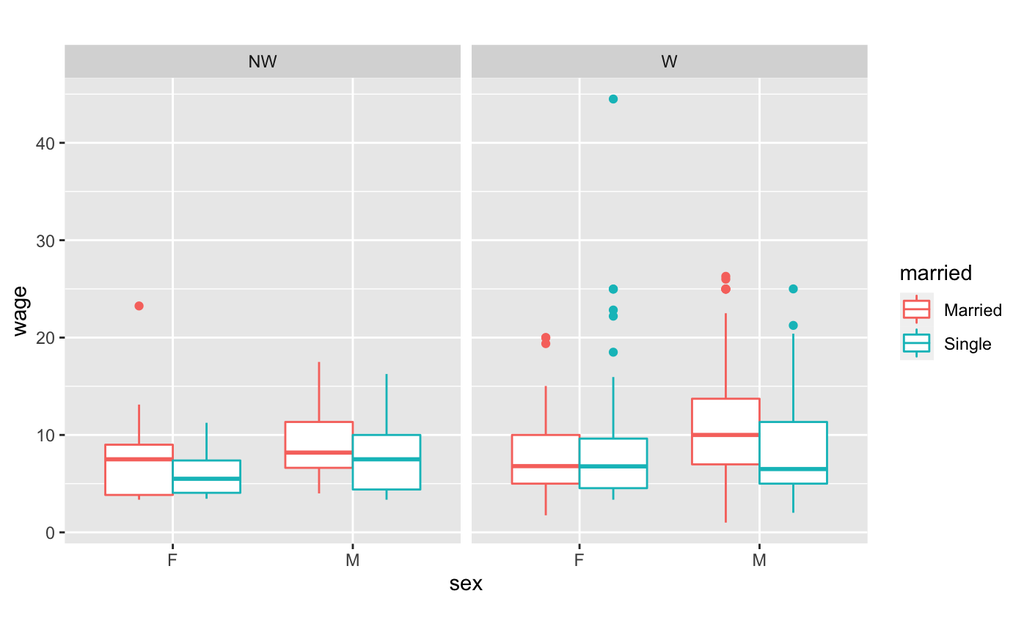

```r
library(mosaic)
library(mosaicData)
library(manipulate)


gf_boxplot(wage ~ sex, data = CPS85, color = ~ married) %>%
gf_facet_wrap(~ race, ncol = 4) %>%
gf_theme(legend.position = "right") %>%
gf_labs(title = "", caption = "")
```

### Problem 5.2

###Problem 5.3

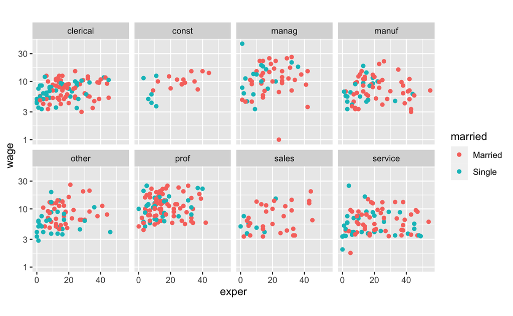

```r
library(mosaic)
library(mosaicData)
library(manipulate)

gf_point(wage ~ exper, data = CPS85, color = ~ married) %>%
gf_refine(scale_y_log10()) %>%
gf_facet_wrap(~ sector, ncol = 4) %>%
gf_theme(legend.position = "right") %>%
gf_labs(title = "", caption = "")
```

## Chapter 6 Exercises

### Problem 6.1

The labels and identifiers for the chart are 1433B, 1433E, 1433G, 1443Z. The frames are not the same in in each face because the percentages are different. In graphs 1433B and 1443Z there are outliers, while in the other two graphs there are not.

###Problem 6.2

Some of the guides in graph include x and y axises which represent genes and log enzymes. Also whether uptake systems and CcPN targets. The way the glyphs are mapped is the x axis represents genes, while the y axis represents log enzymes. The color represents the molecule and whether it is filled or not represents the flux. The variables log and genes both set the frame for the graph. The two horiztonal variables that represent scaling are target and gene.

###Problem 6.3 ’ The set of graphical sets that are mapped to attributes are range and color. The variables for the vertical coordinates is log 2 ratio and the horizontal is high cell density. Color is an attribute of the glyph. There are no guides.

###Problem 6.4

The frame of the graph is the time of a certain ammount of a delay during a certain time. The different types of glyphs used are lines that represent time and how the volume of delay is during each glyph. The information that is included in the style of the glyph of is the time of the mass transit system in California and any delays. The information that is encoded in to the position of the graph is the time frame. The guides are time and date.

###Problem 6.5 B

###Problem 6.6 D

###Problem 6.7 A

###Problem 6.8 E

###Problem 6.9 The frame is defined by weight and BMI and the color each glpyh indicates if the person is a smoker or not.

###Problem 6.10 In the layer of the frame, it is each molecule defined by the key on the left of the graph. The scales that define the space in each time frame are the amount of Viruses, Eukarayotes, Bacteria, and Archarea